# dbscan

Fernando Menendez

October 15, 2018

# Aproximacion del problema mediante clustering por densidad

## Introduccion

Dado el dataset de estrellas de Hiparcos y el set de Hyades identificadas previamente se procede a realizar experimentos de clustering por densidad mediante el algoritmo DBSCAN de la libreria fpc. En los mismos se hara enfasis en los siguientes puntos:

*Seleccion de Variables del dataset origen* Hiperparametrizacion de *eps* y *minPts* *Revision de la presencia de Hyades en los clusters

Para este ultimo punto se intentará identificar cluster relativamente pequeños que contengan la mayor cantidad de las Hyades previamente señaladas como tales.

## Constuccion de los experimentos

Los experimentos con el algoritmo se construyen a partir de los siguientes pasos:

1. Generacion de knnDistPlots sobre los *minPts* cadidatos a fin de identificar los limites superior e inferior de *eps* para la parametrizacion.
2. Ejecucion y extraccion de resultados identificando para cada cluster de cada ejecucion la cantidad de Hyades (definidas)
3. ilustracion de maxima cantidad de hyades en un cluster por ejecucion, tamaño del cluster y tamaño del cluster en relacion a la cantidad de hyades presentes (ratio)
4. Conclusion y extraccion de candidatas cuando corresponda.

## Definiciones

*Se definio como rango de *minPts* de 5 a 50 arbitrariamente.* Se establecieron 4 grandes experimentos variando las variables seleccionadas

1. Medidas de Posicion (RA y DE)
2. Vmag y B.V
3. Todas las variables de Hiparcos
4. Todas las variables, con exepcion de las medidas de posicion

*Para cada salida de la hyperparametrizacion, se identifica visualmente si alguno de los test es aceptable para producir candidatos

## Revision de Hyparcos

```r
hip<-read.csv("..\\02.Preprocesamiento\\hip_version1.csv")
summarizeColumns(hip)
```

```
##            name    type na          mean         disp        median
## 1           HIP numeric  0  2.121964e+04 4.322034e+03  2.109250e+04
## 2      RA_J2000 numeric  0  4.876836e-01 2.836723e-01  4.936358e-01
## 3      DE_J2000 numeric  0  5.031920e-01 2.921657e-01  5.034610e-01
## 4           Plx numeric  0 -5.296291e-17 1.000000e+00 -2.766067e-01
## 5          pmRA numeric  0  2.116658e-17 1.000000e+00 -2.368588e-01
## 6          pmDE numeric  0 -2.282410e-18 1.000000e+00  2.231431e-01
## 7          Vmag numeric  0 -5.573271e-16 1.000000e+00  5.388526e-02
## 8           B.V numeric  0  2.108072e-17 1.000000e+00 -1.720137e-01
## 9 Symbad_Hyades logical  0            NA 1.893939e-02            NA
##            mad           min          max nlevs
## 1 5368.4946000 13510.0000000 28887.000000     0
## 2    0.3600514     0.0000000     1.000000     0
## 3    0.3777898     0.0000000     1.000000     0
## 4    0.4133056    -0.8723429    16.265614     0
## 5    0.2557236    -4.7244992    26.449728     0
## 6    0.2262000   -21.2811893     3.696902     0
## 7    0.8845585    -5.2524243     2.887028     0
## 8    0.9814142    -1.8610277     5.343554     0
## 9           NA    50.0000000  2590.000000     2
```

```r
#nrow(hip)
```

# Experimento 1 - Medidas de Posicion

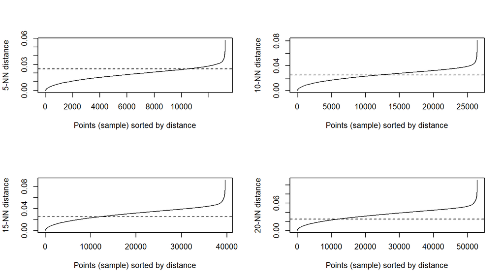

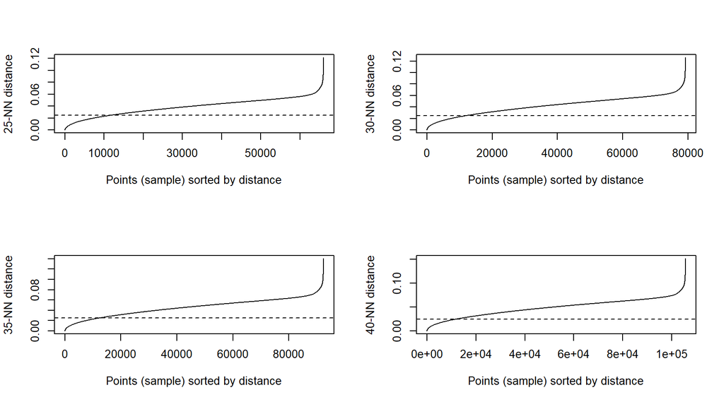

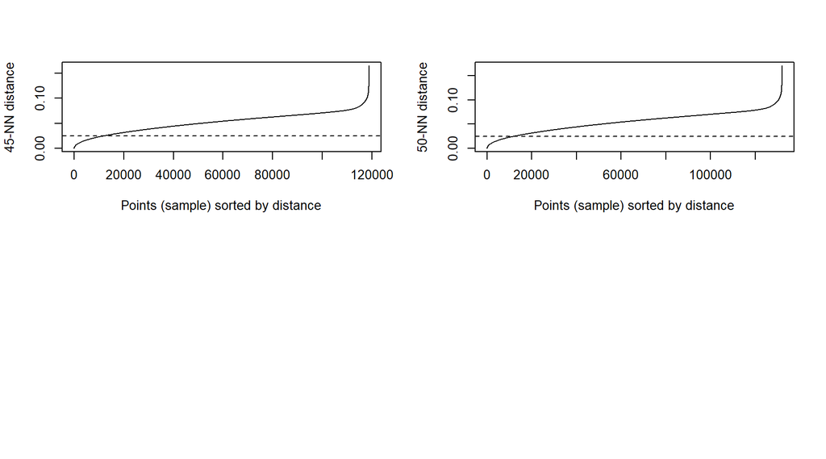

```r
par(mfrow=c(2,2))
df<-hip %>% select(RA_J2000,DE_J2000)
for (i in seq(5,50,5)) {
  kNNdistplot(df,i)
  abline(h = .025, lty=2)
}
```

- Se define el *eps* entre 0.02 y 0.1

```r
tbl.pos<-run_dbscan(df, seq(.02,.1,.01), seq(5,50,1))
```

```r
tbl.pos.rt<-tbl.pos %>% mutate(total=Hyades + No_Hyades,ratio=round(Hyades/total,2)) %>% filter(cls!=0) %>% group_by(test) %>% mutate(total_cls=n()) %>% filter(Hyades==max(Hyades),ratio>.2) %>% ungroup() %>% arrange(test)
tbl.pos.rt
```

```
## # A tibble: 34 x 9
##    cls   Hyades No_Hyades   eps minPts test  total ratio total_cls
##    <chr>  <dbl>     <dbl> <dbl>  <dbl> <fct> <dbl> <dbl>     <int>
##  1 19         7        16  0.02      7 3        23 0.3          49
##  2 7          5        12  0.02      8 4        17 0.290        17
##  3 3          5        10  0.02      9 5        15 0.33          6
##  4 2          5         7  0.02     10 6        12 0.42          2
##  5 2          5         7  0.02     11 7        12 0.42          2
##  6 42        23        83  0.03     10 52      106 0.22         80
##  7 25        21        72  0.03     11 53       93 0.23         57
##  8 8          9        19  0.03     13 55       28 0.32         20
##  9 6          7        16  0.03     14 56       23 0.3          11
## 10 5          6        16  0.03     15 57       22 0.27         10
## # ... with 24 more rows
```

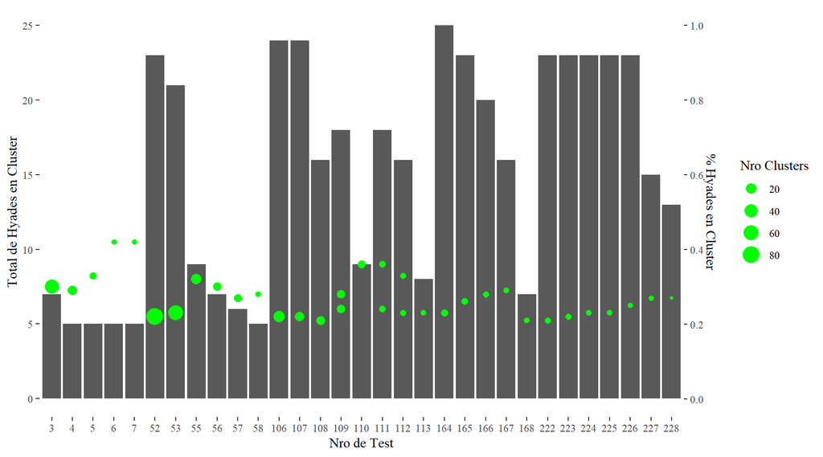

```r
ggplot(data = tbl.pos.rt, aes(x=test)) +
  geom_bar(aes(y=Hyades),stat="identity") +
  geom_point(aes(y=ratio/4*100,size=total_cls),color="green", stat = "identity") +
  scale_y_continuous(name="Total de Hyades en Cluster",breaks = seq(0,50,5),
                     sec.axis = sec_axis(~.*4/100,breaks = seq(0,1,.20), name = "% Hyades en Cluster")) +
#  ylab("Total de Hyades en Cluster") +
  xlab("Nro de Test") +
  labs(size="Nro Clusters") +
#  scale_x_continuous(breaks=seq(1,150,1)) +
  theme_tufte()
```

**OBS:** No se visualizan clusters que presenten suficientes Hyades para tomar otras candidatas

## Normalizacion de Variables

```r
hip.scaled<-hip %>% mutate_at(.funs = funs(scale(.,center = T, scale = T)), .vars = vars(-HIP,-Symbad_Hyades))
```

## Experimento 2 - B.V y Vmag

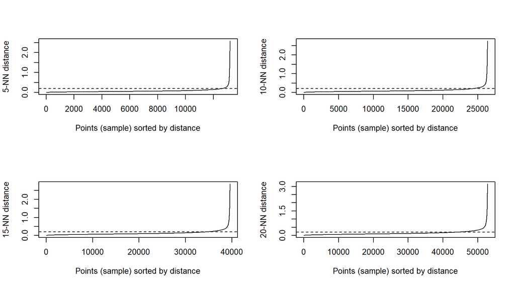

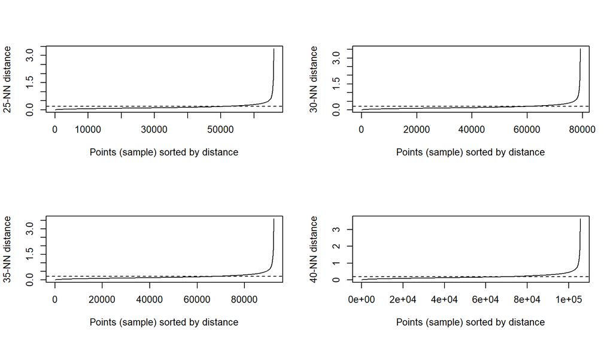

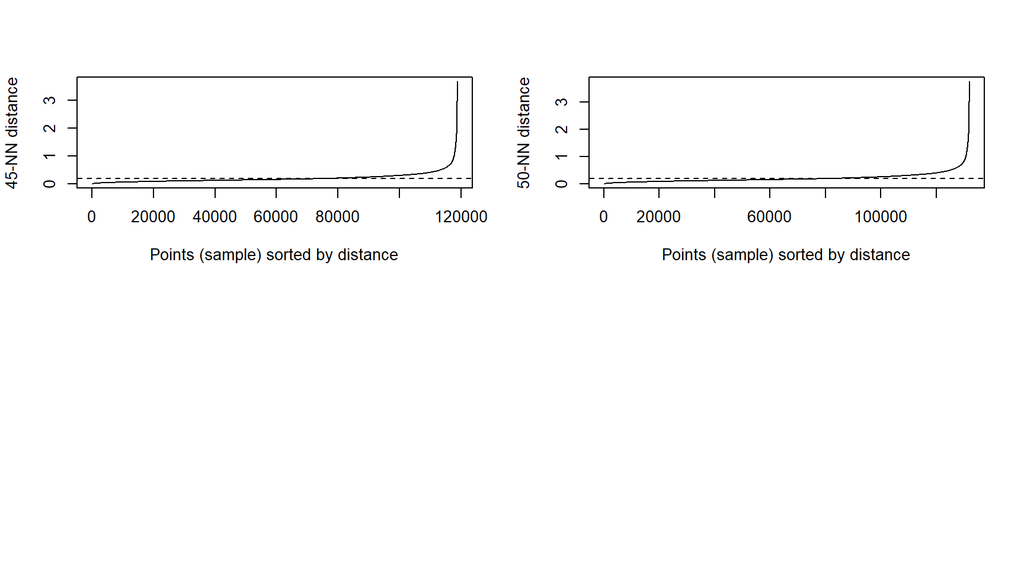

```r
par(mfrow=c(2,2))
df2<-hip.scaled %>% select(Vmag,B.V)
for (i in seq(5,50,5)) {
  kNNdistplot(df2,i)
  abline(h = .2, lty=2)
}
```

- Se define el *eps* entre 0.1 y 1

```r
tbl.vb<-run_dbscan(df2,seq(.1,1,.1),seq(5,50,1))
```

```r
tbl.vb.rt<-tbl.vb %>% mutate(total=Hyades + No_Hyades,ratio=round(Hyades/total,2)) %>% filter(cls!=0) %>% group_by(test) %>% mutate(total_cls=n()) %>% filter(Hyades==max(Hyades), ratio>.1) %>% ungroup() %>% arrange(desc(ratio))
tbl.vb.rt
```

```
## # A tibble: 2 x 9
##   cls   Hyades No_Hyades   eps minPts test  total ratio total_cls
##   <chr>  <dbl>     <dbl> <dbl>  <dbl> <fct> <dbl> <dbl>     <int>
## 1 8          6        20   0.1     18 14       26  0.23        12
## 2 6          6        31   0.1     17 13       37  0.16         9
```

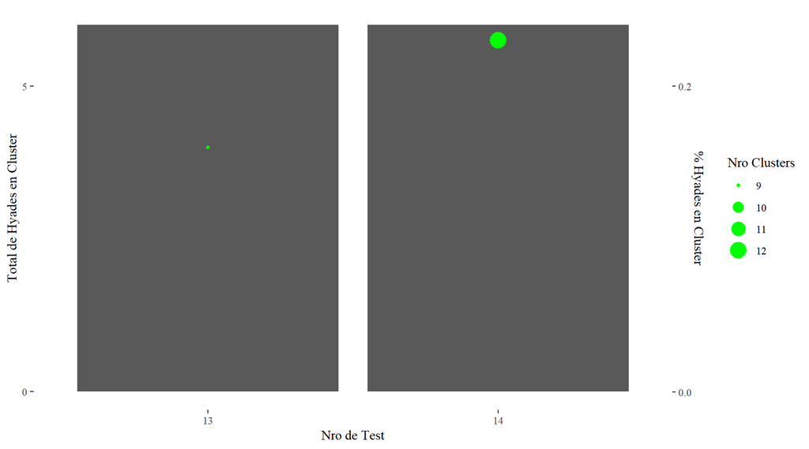

```r
ggplot(data = tbl.vb.rt, aes(x=test)) +
  geom_bar(aes(y=Hyades),stat="identity") +
  geom_point(aes(y=ratio/4*100,size=total_cls),color="green", stat = "identity") +
  scale_y_continuous(name="Total de Hyades en Cluster",breaks = seq(0,50,5),
                     sec.axis = sec_axis(~.*4/100,breaks = seq(0,1,.20), name = "% Hyades en Cluster")) +
#  ylab("Total de Hyades en Cluster") +
  xlab("Nro de Test") +
  labs(size="Nro Clusters") +
#  scale_x_continuous(breaks=seq(1,150,1)) +
  theme_tufte()
```

**OBS:** No se visualizan clusters que presenten suficientes Hyades para tomar otras candidatas

## Experimento 3 - Full dataset

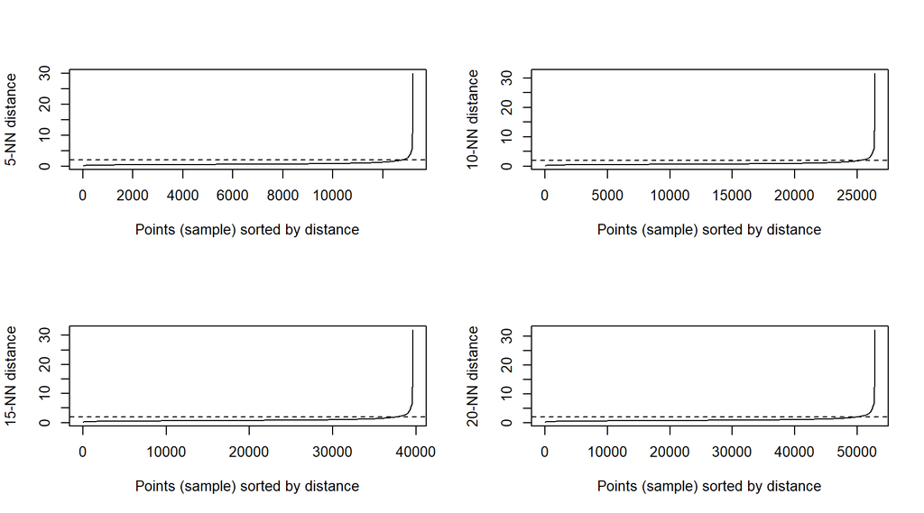

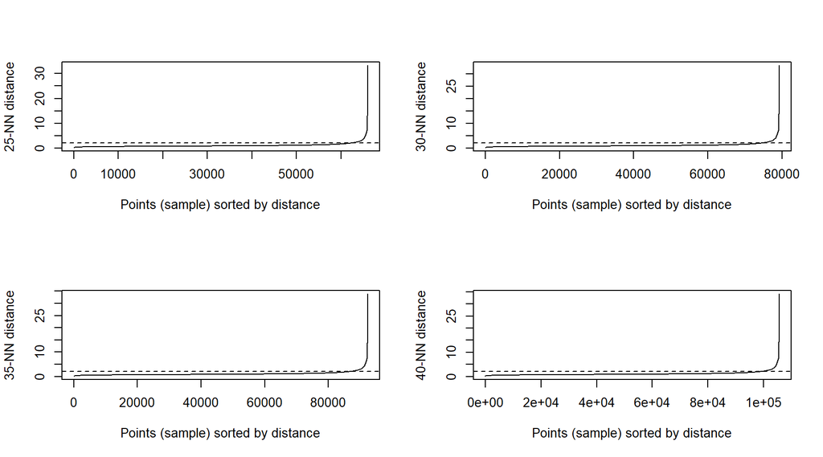

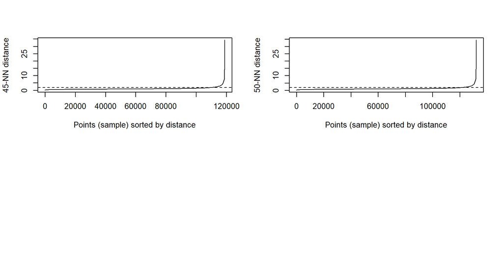

```r
par(mfrow=c(2,2))
df3<-hip.scaled %>% select(-HIP,-Symbad_Hyades)
for (i in seq(5,50,5)) {
  kNNdistplot(df3,i)
  abline(h = 2, lty=2)
}
```

- Se define el *eps* entre 0.5 y 2

```r
tbl.full<-run_dbscan(df3,seq(.5,2,.1),seq(5,50,1))
```

```r
tbl.full.rt<-tbl.full %>% mutate(total=Hyades + No_Hyades,ratio=round(Hyades/total,2)) %>% filter(cls!=0) %>% group_by(test) %>% mutate(total_cls=n()) %>% filter(Hyades==max(Hyades), ratio>.5) %>% ungroup() %>% arrange(desc(ratio))
tbl.full.rt
```

```
## # A tibble: 17 x 9
##    cls   Hyades No_Hyades   eps minPts test  total ratio total_cls
##    <chr>  <dbl>     <dbl> <dbl>  <dbl> <fct> <dbl> <dbl>     <int>
##  1 4          8         1   0.5     11 7         9  0.89         9
##  2 3         15         9   0.6     17 59       24  0.62         8
##  3 3         10         8   0.6     18 60       18  0.56         8
##  4 2         15        12   0.7     25 113      27  0.56         2
##  5 2         15        12   0.7     26 114      27  0.56         2
##  6 2         15        12   0.7     27 115      27  0.56         3
##  7 3         27        21   1       48 274      48  0.56         3
##  8 2         29        24   0.8     31 165      53  0.55         3
##  9 2         26        23   0.8     32 166      49  0.53         2
## 10 2         18        16   0.8     34 168      34  0.53         2
## 11 2         26        23   0.9     41 221      49  0.53         3
## 12 2         23        20   0.9     42 222      43  0.53         3
## 13 2         23        20   0.9     43 223      43  0.53         3
## 14 3         11        10   0.6     19 61       21  0.52         7
## 15 2         11        10   0.6     20 62       21  0.52         5
## 16 1         11        10   0.6     21 63       21  0.52         4
## 17 3         31        30   1       47 273      61  0.51         3
```

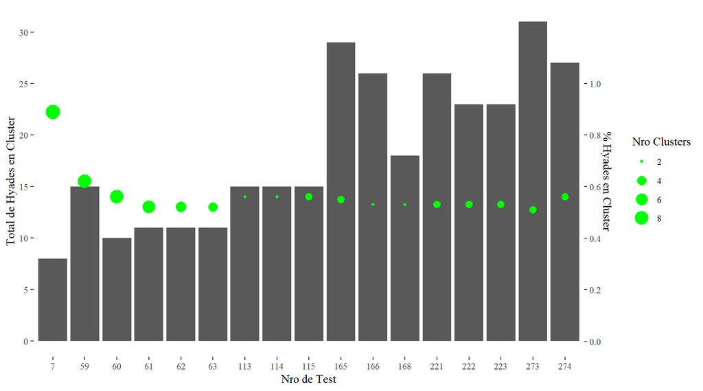

```r
ggplot(data = tbl.full.rt, aes(x=test)) +
  geom_bar(aes(y=Hyades),stat="identity") +
  geom_point(aes(y=ratio/4*100,size=total_cls),color="green", stat = "identity") +
  scale_y_continuous(name="Total de Hyades en Cluster",breaks = seq(0,50,5),
                     sec.axis = sec_axis(~.*4/100,breaks = seq(0,1,.20), name = "% Hyades en Cluster")) +
#  ylab("Total de Hyades en Cluster") +
  xlab("Nro de Test") +
  labs(size="Nro Clusters") +
#  scale_x_continuous(breaks=seq(1,150,1)) +
  theme_tufte()
```

```r
tbl.full %>% filter(test==273)
```

```
## # A tibble: 4 x 6
## # Groups:   cls [4]
##   cls   Hyades No_Hyades   eps minPts test
##   <chr>  <dbl>     <dbl> <dbl>  <dbl> <fct>
## 1 0         19       919     1     47 273
## 2 1          0      1556     1     47 273
## 3 2          0        85     1     47 273
## 4 3         31        30     1     47 273
```

```r
set.seed(123)
db <- fpc::dbscan(df3, eps = 1, MinPts = 47)
db
```

```
## dbscan Pts=2640 MinPts=47 eps=1
##          0    1  2  3
## border 938  708 81 58
## seed     0  848  4  3
## total  938 1556 85 61
```

```r
cand<- data.frame(HIP=hip$HIP,Symbad_Hyades=hip$Symbad_Hyades,Cluster=db$cluster) %>% filter(Cluster==3)
cand
```

```
##      HIP Symbad_Hyades Cluster
## 1  18170          TRUE       3
## 2  18735         FALSE       3
## 3  19148         FALSE       3
## 4  19261          TRUE       3
## 5  19504          TRUE       3
## 6  19781          TRUE       3
## 7  19786         FALSE       3
## 8  19796          TRUE       3
## 9  19877          TRUE       3
## 10 20019         FALSE       3
## 11 20056         FALSE       3
## 12 20146         FALSE       3
## 13 20215          TRUE       3
## 14 20237         FALSE       3
```

[output cut: 47 more lines]

## Experimento 4 - Sin distancias

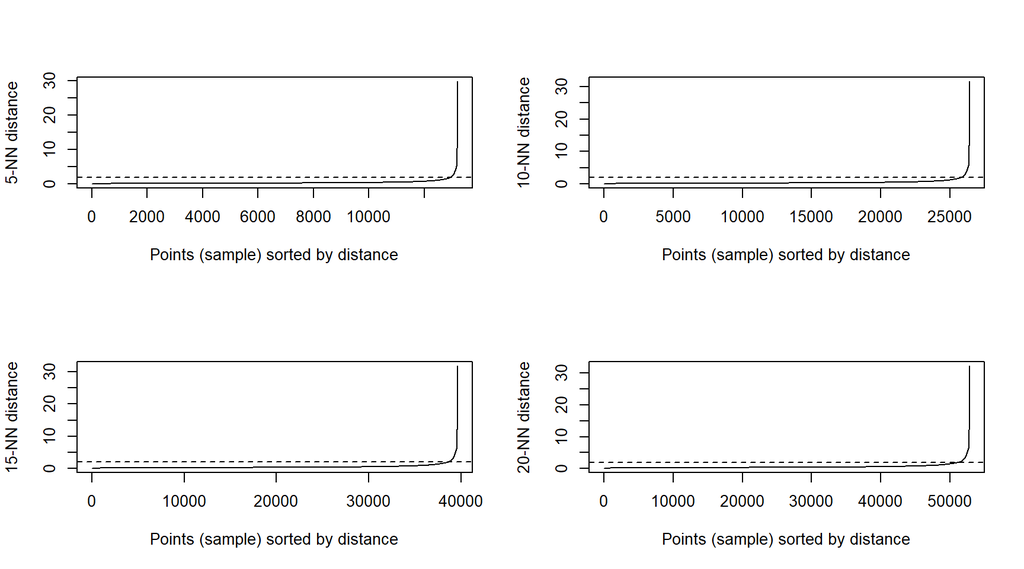

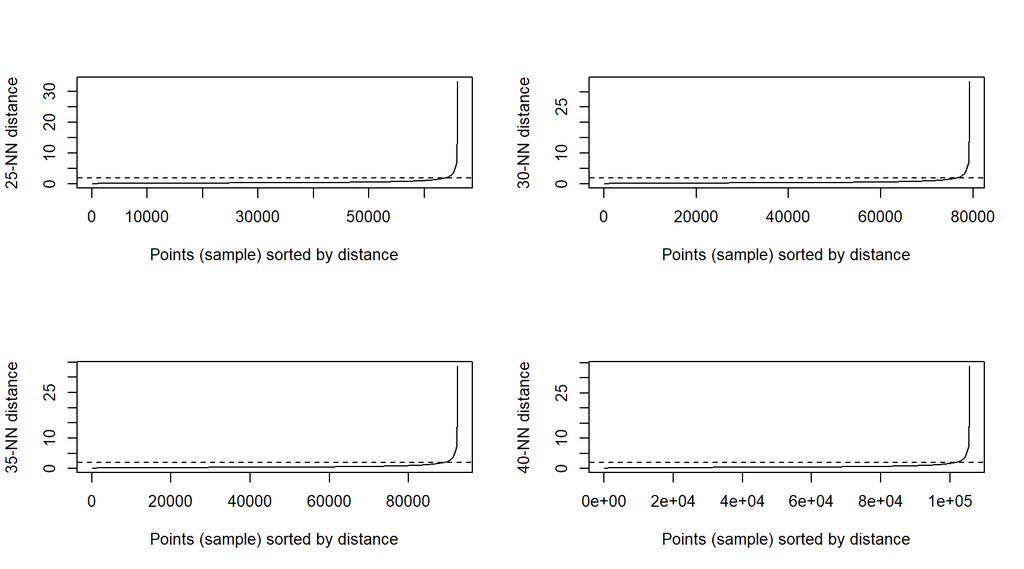

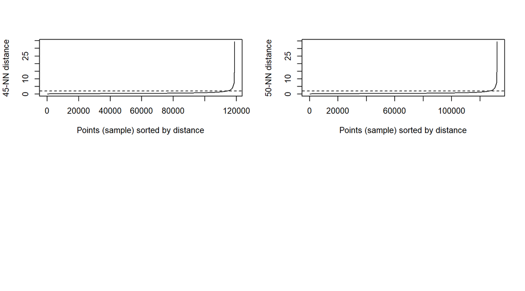

```r
par(mfrow=c(2,2))
df4<-hip.scaled %>% select(-HIP,-Symbad_Hyades,-RA_J2000,-DE_J2000)
for (i in seq(5,50,5)) {
  kNNdistplot(df4,i)
  abline(h = 2, lty=2)
}
```

- Se define el *eps* entre 0.5 y 2

```r
tbl.ndis<-run_dbscan(df4,seq(.5,2,.1),seq(5,50,1))
```

```r
tbl.ndis.rt<-tbl.ndis %>% mutate(total=Hyades + No_Hyades,ratio=round(Hyades/total,2)) %>% filter(cls!=0) %>% group_by(test) %>% mutate(total_cls=n()) %>% filter(Hyades==max(Hyades), ratio>.5) %>% ungroup() %>% arrange(desc(ratio))
tbl.ndis.rt
```

```
## # A tibble: 26 x 9
##    cls   Hyades No_Hyades   eps minPts test  total ratio total_cls
##    <chr>  <dbl>     <dbl> <dbl>  <dbl> <fct> <dbl> <dbl>     <int>
##  1 2         28        16   0.5     29 25       44 0.64          2
##  2 2         28        17   0.5     27 23       45 0.62          2
##  3 2         28        17   0.5     28 24       45 0.62          2
##  4 2         24        15   0.5     30 26       39 0.62          2
##  5 2         30        23   0.6     37 79       53 0.570         2
##  6 2         31        24   0.6     34 76       55 0.56          2
##  7 2         30        24   0.6     35 77       54 0.56          2
##  8 2         30        24   0.6     36 78       54 0.56          2
##  9 2         28        22   0.6     38 80       50 0.56          2
## 10 2         28        22   0.6     39 81       50 0.56          2
## # ... with 16 more rows
```

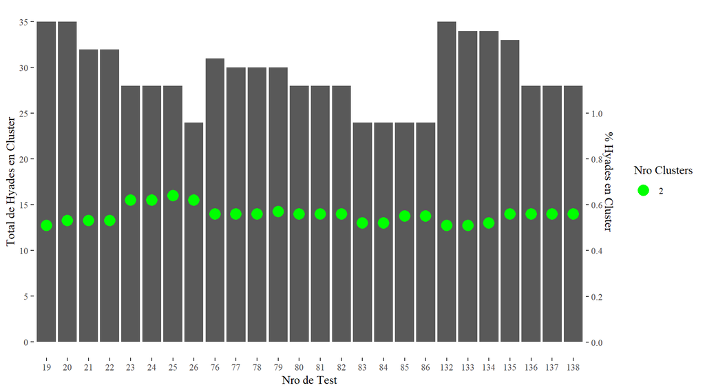

```r
ggplot(data = tbl.ndis.rt, aes(x=test)) +
  geom_bar(aes(y=Hyades),stat="identity") +
  geom_point(aes(y=ratio/4*100,size=total_cls),color="green", stat = "identity") +
  scale_y_continuous(name="Total de Hyades en Cluster",breaks = seq(0,50,5),
                     sec.axis = sec_axis(~.*4/100,breaks = seq(0,1,.20), name = "% Hyades en Cluster")) +
#  ylab("Total de Hyades en Cluster") +
  xlab("Nro de Test") +
  labs(size="Nro Clusters") +
#  scale_x_continuous(breaks=seq(1,150,1)) +
  theme_tufte()
```

**OBS:** Resaltan las ejecuciones 19 132. Nuevamente, repito el experimento para encontrar candidatas

```r
tbl.ndis.rt %>% filter(test %in% c(19,132))
```

```
## # A tibble: 2 x 9
##   cls   Hyades No_Hyades   eps minPts test  total ratio total_cls
##   <chr>  <dbl>     <dbl> <dbl>  <dbl> <fct> <dbl> <dbl>     <int>
## 1 2         35        34   0.5     23 19       69  0.51         2
## 2 2         35        34   0.7     44 132      69  0.51         2
```

```r
tbl.ndis %>% filter(test %in% c(19,132))
```

```
## # A tibble: 6 x 6
## # Groups:   cls [3]
##   cls   Hyades No_Hyades   eps minPts test
##   <chr>  <dbl>     <dbl> <dbl>  <dbl> <fct>
## 1 0         15       684   0.5     23 19
## 2 1          0      1872   0.5     23 19
## 3 2         35        34   0.5     23 19
## 4 0         15       508   0.7     44 132
## 5 1          0      2048   0.7     44 132
## 6 2         35        34   0.7     44 132
```

```r
set.seed(123)
db <- fpc::dbscan(df4, eps = .5, MinPts = 23)
db
```

```
## dbscan Pts=2640 MinPts=23 eps=0.5
##          0    1  2
## border 699  374 49
## seed     0 1498 20
## total  699 1872 69
```

```r
cand2<- data.frame(HIP=hip$HIP,Symbad_Hyades=hip$Symbad_Hyades,Cluster=db$cluster) %>% filter(Cluster==2) %>% arrange(HIP)
cand2
```

```
##      HIP Symbad_Hyades Cluster
## 1  18658          TRUE       2
## 2  18735         FALSE       2
## 3  19148         FALSE       2
## 4  19261          TRUE       2
## 5  19504          TRUE       2
## 6  19781          TRUE       2
## 7  19786         FALSE       2
## 8  19789         FALSE       2
## 9  19793         FALSE       2
## 10 19796          TRUE       2
## 11 19870         FALSE       2
## 12 19877          TRUE       2
## 13 20019         FALSE       2
## 14 20056         FALSE       2
```

[output cut: 55 more lines]

```r
set.seed(123)
db <- fpc::dbscan(df4, eps = .7, MinPts = 44)
db
```

```
## dbscan Pts=2640 MinPts=44 eps=0.7
##          0    1  2
## border 523  303 55
## seed     0 1745 14
## total  523 2048 69
```

```r
cand3<- data.frame(HIP=hip$HIP,Symbad_Hyades=hip$Symbad_Hyades,Cluster=db$cluster) %>% filter(Cluster==2) %>% arrange(HIP)
cand3
```

```
##      HIP Symbad_Hyades Cluster
## 1  14152         FALSE       2
## 2  15565         FALSE       2
## 3  18658          TRUE       2
## 4  19148         FALSE       2
## 5  19261          TRUE       2
## 6  19504          TRUE       2
## 7  19781          TRUE       2
## 8  19786         FALSE       2
## 9  19789         FALSE       2
## 10 19793         FALSE       2
## 11 19796          TRUE       2
## 12 19870         FALSE       2
## 13 19877          TRUE       2
## 14 20019         FALSE       2
```

[output cut: 55 more lines]

## Revision de Candidatas

Se cruzan las estrellas candidatas de los experimentos resaltados anteriormente

```r
cand.fil<-cand %>% filter(Symbad_Hyades==FALSE)
cand2.fil<-cand2 %>% filter(Symbad_Hyades==FALSE)
cand3.fil<-cand3 %>% filter(Symbad_Hyades==FALSE)
cand.list <- cand.fil %>% inner_join(cand2.fil, by = "HIP") %>% inner_join(cand3.fil, by = "HIP") %>% select(HIP)
cand.list
```

```
##      HIP
## 1  19148
## 2  19786
## 3  20019
## 4  20056
## 5  20146
## 6  20237
## 7  20255
## 8  20284
## 9  20440
## 10 20553
## 11 20614
## 12 20686
## 13 20719
## 14 20826
## 15 21112
## 16 21137
## 17 21543
## 18 21654
## 19 22203
## 20 22422
## 21 22496
## 22 22505
## 23 22826
```

```r
write.csv(cand.list, "DBSCAN - Candidatas.csv")
```